# Individual Differences of Quantifier Interpretation

Julia Haaf

6/3/2019

```r
library("MCMCpack")
library("LaplacesDemon")
library("rstan")
library("plotrix")
```

**To Do:**

- Better cleaning
- Compute Bayes factor
- Extend to other quantifiers (many < more than half < most vs. more than half < most < many)
- Mirrored quantifiers should be the same, maybe

Collect new data set, maybe?

## The Task (How I understand it)

In this task, participants have to evaluate whether a certain quantifier logically describes a scenario. Scenarios are percentages of, for example, apples that are green. Say, 20% of apples are green, is the statement that “most of the apples are green” true or false? Percentages are drawn from a uniform ensuring that as many trials have more than 50% as have less than 50%. The quantifiers of interest are *Most* and *More than half*. The idea is that *More than half* is defined by more than 50% for everyone while *Most* may be more subjective, and it may be more than *More than half* for everyone.

## Modeling Approach

I think we could use a probit regression with a participant-specific quantifier effect and a participant-specific effect of percentage used. This way we could at least assess whether *Most* is more than *More than half* by defining the quantifier effect as a contrast between the two. It could even be tested in this framework whether *More than half* is 50% for everyone.

### Model

Let $i$ indicate participants, $i = 1, \ldots, I$, $j$ indicate the quantifier, $j = 1, 2$, and $k$ indicate the trial for each quantifier, $k = 1, \ldots, 50$. Then $Y_{ijk}$ is the $i$th participant’s response to the $j$th quantifier in the $k$th trial, and $Y_{ijk} = 1$ if participants indicate *true*, and $Y_{ijk} = 0$ if participant indicate *false*. Then, we may model $Y_{ijk}$ as a Bernoulli, using the probit link function on the probabilities:

$$\begin{align*}
Y_{ijk} &\sim \mbox{Bernoulli}(\pi_{ijk}),\\
\mu_{ijk} &= \Phi^{-1}(\pi_{ijk}),\\
\end{align*}$$

where the second line maps the probability space of $\pi$ onto the real space of $\mu$. We may now place a linear model on $\mu_{ijk}$:

$$\mu_{ijk} = \beta_{i0} + l_{ijk}\beta_{i1} + h_{ijk}\beta_{i2} + z_{ij} \beta_{i3},$$

where $l_{ijk}$, $h_{ijk}$ and $z_{ij}$ are predictors: $l_{ijk}$ is zero for percentages above 50%, and indicates the percentage otherwise; $xh{ijk}$ is zero for percentages below 50%, and indicates the percentage otherwise, and $z_{ij}$ indicates the quantifier ($z_{ij} = 0$ for *More than half*, and $z_{ij} = 1$ for *Most*). Parameters $\beta_{i0}$ are random intercepts, $\beta_{i1}$ are random percentage effects for percentages below 50%, $\beta_{i12}$ are random percentage effects for percentages above 50%, and $\beta_{i3}$ are random quantifier effects. For now, I will place the following priors:

$$\begin{align*}
\beta_{i0} &\sim \mbox{Normal}(0, \sigma_0^2),\\
\beta_{i1} &\sim \mbox{Normal}(\delta_1, \sigma_1^2),\\
\beta_{i2} &\sim \mbox{Normal}(\delta_2, \sigma_2^2),\\
\beta_{i3} &\sim \mbox{Normal}(\delta_3, \sigma_3^2).\\
\end{align*}$$

### Simulating From the Model

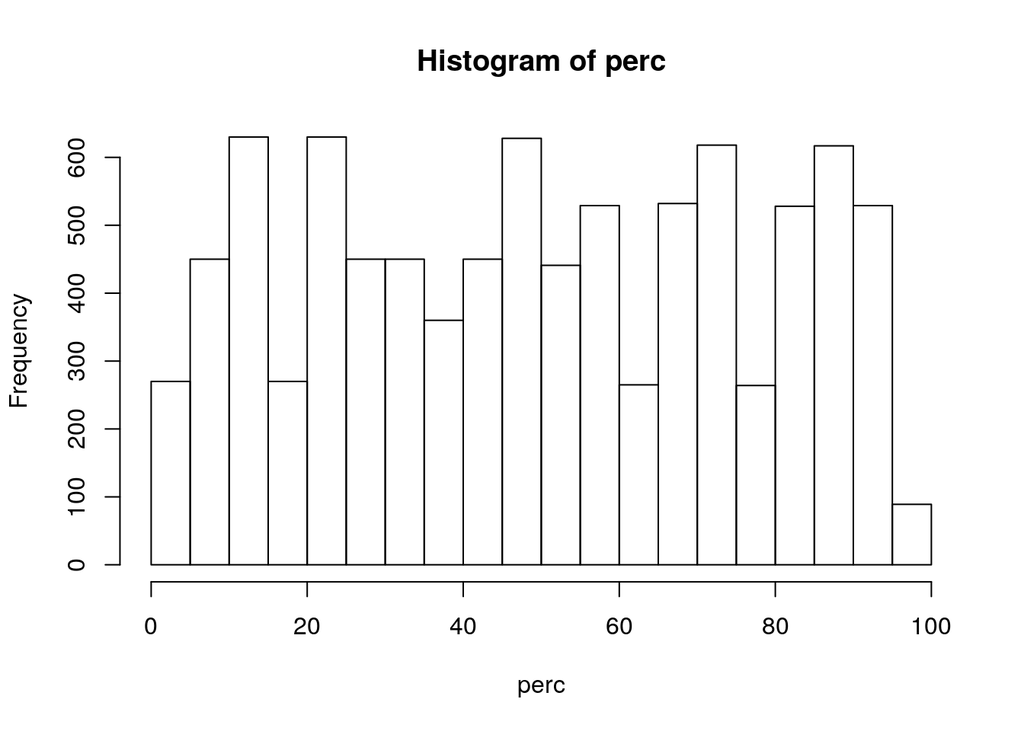

```r
set.seed(123)
I <- 90
J <- 2
K <- 50
sub <- rep(1:I, each = J*K)
quant <- factor(rep(1:J, each = K, times = I), labels = c("More", "Most"))
offperc <- c(quant[26:(I*J*K)], quant[1:25])
perc <- ifelse(offperc == 1, sample(1:50, replace = T), sample(50:100, replace = T))
hist(perc)
```

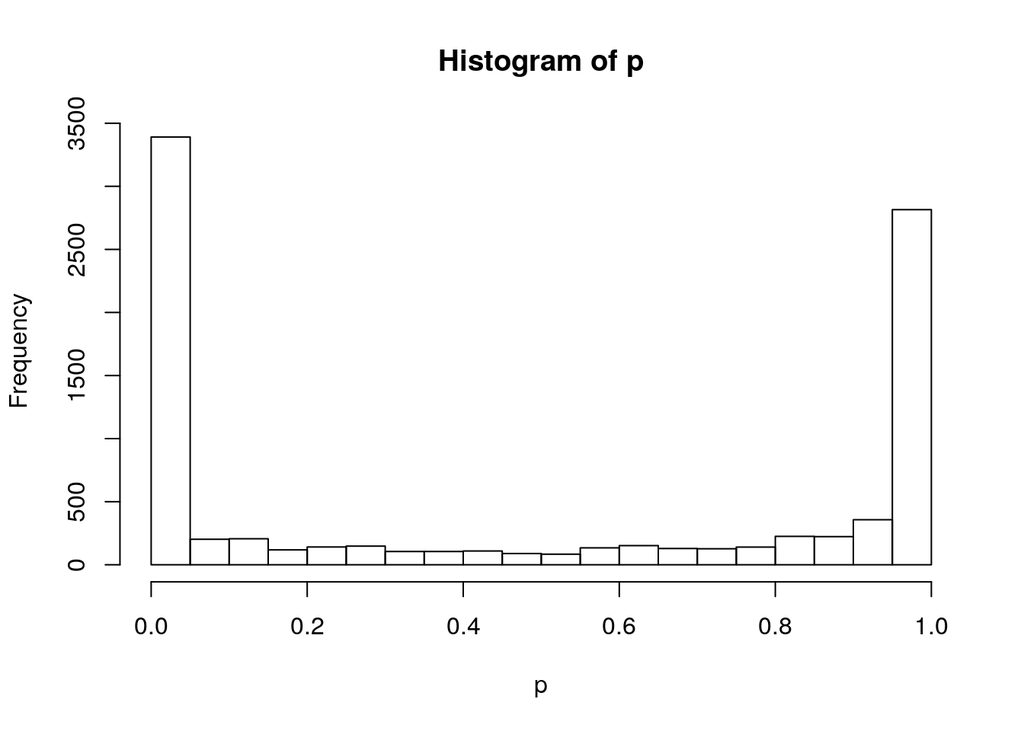

```r
z <- as.numeric(quant) - 1
x <- (perc - 50)/100
l <- (2 - offperc) * x
h <- (offperc - 1) * x

s0 <- 1
s1 <- .05
s2 <- .1
s3 <- .1
d1 <- 15
d2 <- 10
d3 <- -.5

b0 <- rnorm(I, 0, s0)
b1 <- rnorm(I, d1, s1)
b2 <- rnorm(I, d2, s2)
b3 <- rnorm(I, d3, s3)

mu <- b0 + l * b1 + h * b2 + z * b3
p <- pnorm(mu)
hist(p)
```

```r
# p <- invlogit(mu)
# hist(p)
y <- rbinom(I*J*K, 1, p)
table(y, quant)
```

```
##    quant
## y   More Most
##   0 2166 2508
##   1 2334 1992
```

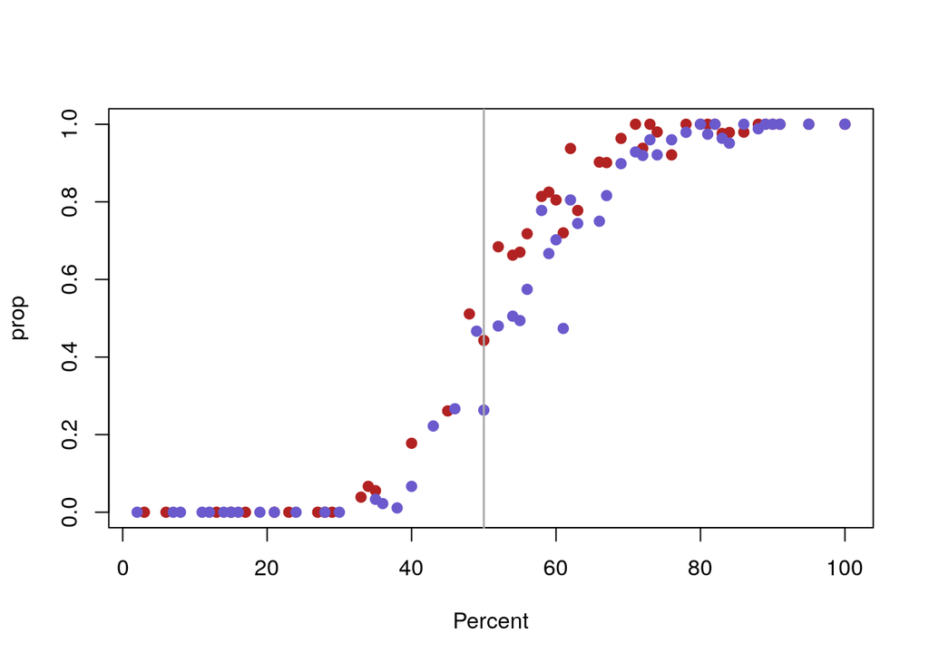

```r
prop <- tapply(y, list(perc, quant), mean)
matplot(as.numeric(rownames(prop)), prop
        , pch = 19, col = c("firebrick", "slateblue")
        , xlab = "Percent")
abline(v = 50, lwd = 1.5, col = "darkgrey")
```

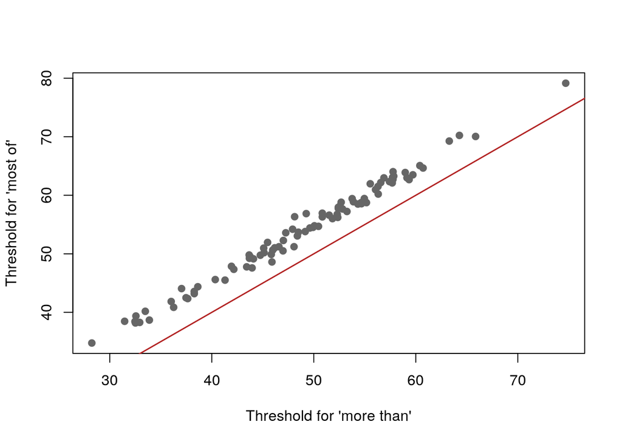

```r
threshmore <- -b0/b2 * 100 + 50
threshmost <- (-b0 - b3)/b2 * 100 + 50

plot(threshmore, threshmost
     , pch = 19, col = "gray40"
     , ylab = "Threshold for 'most of'"
     , xlab = "Threshold for 'more than'")
abline(0, 1, lwd = 1.5, col = "firebrick")
```

### Data

```r
exclude <- c(0, 1, 5, 18, 32, 39, 49, 52, 53, 58, 62, 81, 82, 83, 85, 86, 87)
exclude2 <- c(27, 76)

dat <- read.csv("data/exp1-replication-trials.csv")
head(dat)
```

```
##   workerid       A         B percent read_and_decide_time  quant
## 1        0 "glerb"  "fizzda"      20                 3702  "All"
## 2        0 "thonk" "krangly"      82                  433 "Some"
## 3        0 "slarm" "briddle"      11                  287 "None"
## 4        0 "klong"   "nooty"      62                   16  "All"
## 5        0 "dring"   "larfy"      28                  384 "None"
## 6        0 "floom" "plerful"      92                  126 "Some"
##   read_time_one response
## 1           183    false
## 2           264    false
## 3           216     true
## 4            48     true
## 5           113    false
## 6           104    false
```

```r
nrow(dat)
```

```
## [1] 23220
```

```r
# Exclusion based on Sonia's code
## Participant-level
dat <- subset(dat, !(workerid %in% exclude))
nrow(dat)
```

```
## [1] 18834
```

```r
## Trial-level
dat <- subset(dat, read_and_decide_time > 300)
dat <- subset(dat, read_and_decide_time < 2500)
nrow(dat)
```

```
## [1] 17641
```

```r
table(dat$quant, dat$workerid)[, 1]
```

```
##             "All"             "Few" "Fewer than half"            "Many"
##                 2                48                48                50
##  "More than half"            "Most"            "None"            "Some"
##                50                50                 3                 1
```

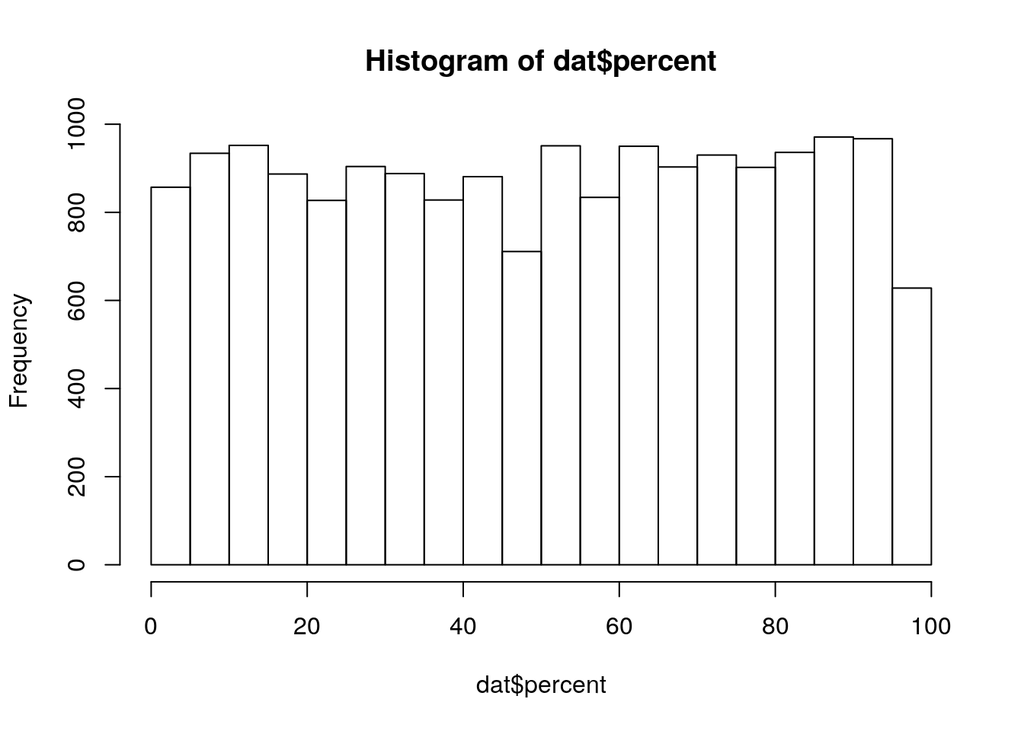

```r
hist(dat$percent)
```

```r
table(dat$percent>50)
```

```
##
## FALSE  TRUE
##  8669  8972
```

```r
table(dat$response, dat$quant)
```

```
##
##         "All" "Few" "Fewer than half" "Many" "More than half" "Most"
##   false    92  2078              1842   1457             1759   1845
##   true     11  1310              1650   1983             1768   1638
##
##         "None" "Some"
##   false    135     13
##   true      10     50
```

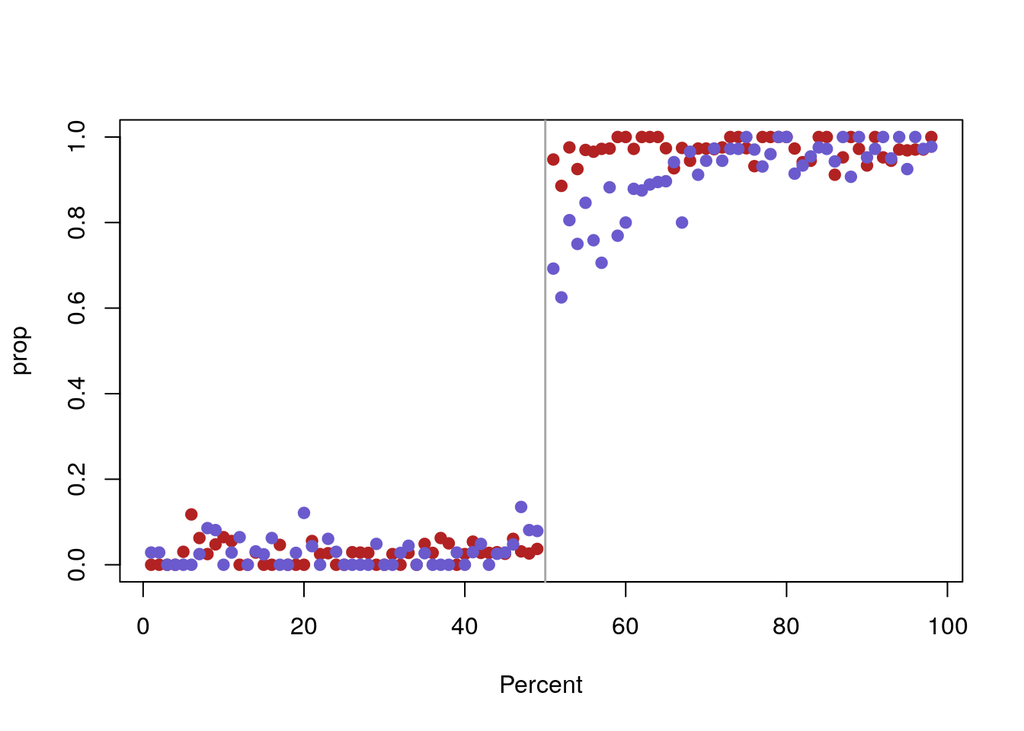

```r
dat$qq <- as.numeric(dat$quant) %in% c(5, 6)

dat <- subset(dat, qq == T)
prop <- tapply(as.numeric(dat$response) - 1, list(dat$percent, dat$quant), mean)
matplot(as.numeric(rownames(prop)), prop
        , pch = 19, col = c("firebrick", "slateblue")
        , xlab = "Percent")
abline(v = 50, lwd = 1.5, col = "darkgrey")
```

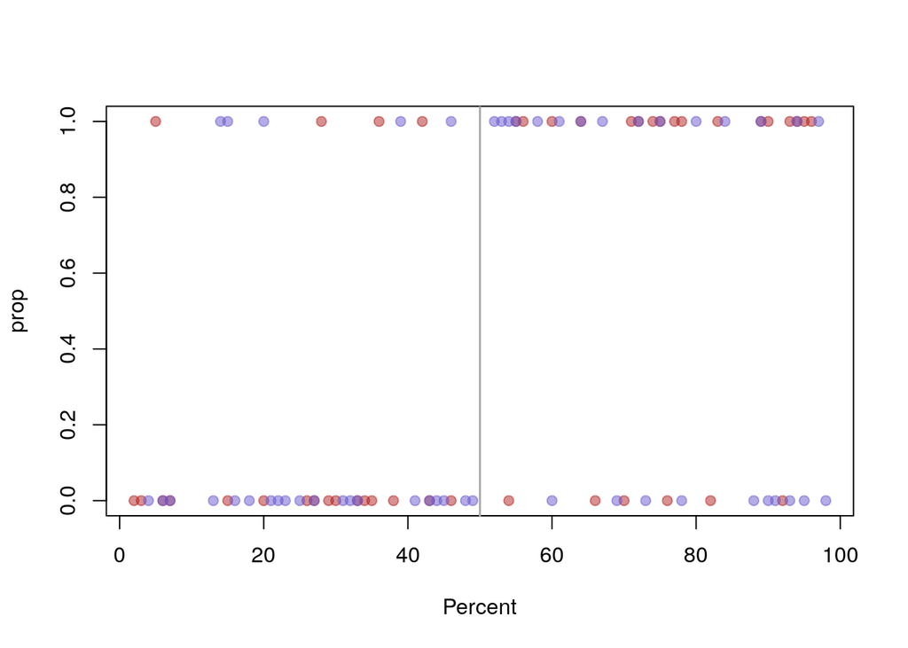

```r
datsub <- subset(dat, workerid == 27)
prop <- tapply(as.numeric(datsub$response) - 1, list(datsub$percent, datsub$quant), mean)
matplot(as.numeric(rownames(prop)), prop
        , pch = 19, col = c(adjustcolor("firebrick", .5), adjustcolor("slateblue", .5))
        , xlab = "Percent")
abline(v = 50, lwd = 1.5, col = "darkgrey")
```

```r
dat <- read.csv("data/exp1-replication-v2-trials.csv")
head(dat)
table(dat$quant, dat$workerid)[, 1]
hist(dat$percent)
table(dat$percent>50)

table(dat$response, dat$quant)
dat$qq <- as.numeric(dat$quant) %in% c(5, 6)

dat <- subset(dat, qq == T)
prop <- tapply(as.numeric(dat$response) - 1, list(dat$percent, dat$quant), mean)
matplot(as.numeric(rownames(prop)), prop
        , pch = 19, col = c("firebrick", "slateblue")
        , xlab = "Percent")
abline(v = 50, lwd = 1.5, col = "darkgrey")
```

### Estimation

#### Priors

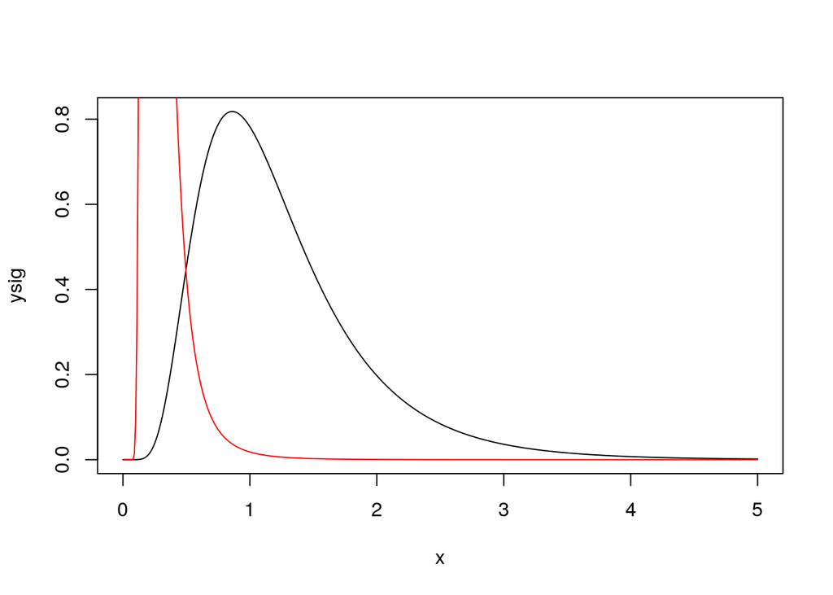

```r
x <- seq(0, 5, .01)
ysig <- dlnorm(x, .1, .5)
ysig2 <- 2 * x * dinvgamma(x^2, 2, .1)
plot(x, ysig, type = "l")
lines(x, ysig2, col = 2)
```

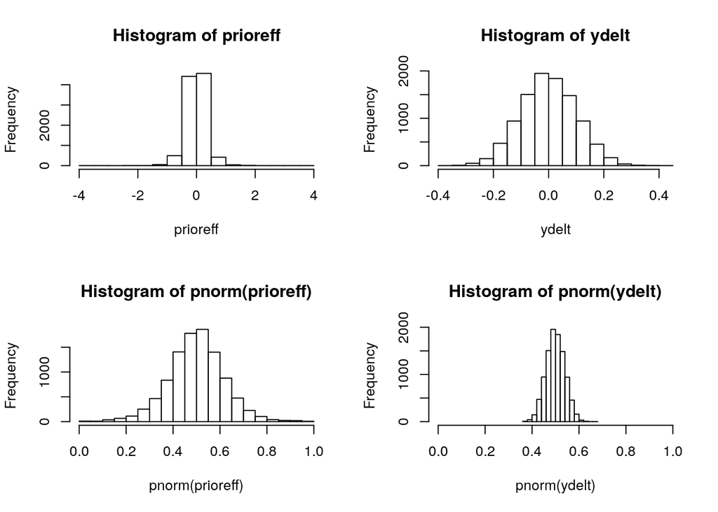

```r
ydelt <- rnorm(x, 0, .1)

M <- 10000
ysig2 <- rinvgamma(M, 2, .1)
ydelt <- rnorm(M, 0, .1)

prioreff <- rnorm(M, ydelt, sqrt(ysig2))

layout(matrix(1:4, ncol = 2, byrow = T))
hist(prioreff)
hist(ydelt)
hist(pnorm(prioreff), xlim = c(0, 1))
hist(pnorm(ydelt), xlim = c(0, 1))
```

#### Model

```r
logmod <- "

data {
  int<lower=1> D;                     // #Dimensions of the model
  int<lower=0> N;                     // #Observations
  int<lower=1> I;                     // #Participants
  int<lower=0,upper=1> y[N];          // Data 0,1
  vector[N] cperc;                    // Centered Percentages
  int<lower=1,upper=I> sub[N];        // participant vector
  int<lower=0,upper=1> quant[N];      // Which quantifier?
  int<lower=0,upper=1> above[N];      // Above 50 percent?
}

parameters {
  real delta[D];                      // Means of betas
  real<lower=0> sigma2[D];             // variance of betas
  vector[D] beta[I];                  // vectors of betas
}

transformed parameters {
  real<lower=0> sigma[D];
  sigma = sqrt(sigma2);
}

model {
  delta ~ normal(0, 5);
  sigma2 ~ inv_gamma(2, .1);
  for (i in 1:I)
    beta[i] ~ normal(delta, sigma);
  for (n in 1:N)
    y[n] ~ bernoulli(Phi_approx(beta[sub[n], 1] + (1 - above[n]) * cperc[n] * beta[sub[n], 2] + above[n] * cperc[n] * beta[sub[n], 3] + quant[n] * beta[sub[n], 4]));
}
"

logmodM <- stan_model(model_code = logmod)
```

```r
getDat <- function(dat){
  D <- 4
  N <- nrow(dat)
  I <- length(unique(dat$workerid))

  y <- as.numeric(dat$response) - 1
  cperc <- (dat$percent - 50) / 100
  sub <- as.numeric(factor(dat$workerid))
  quant <- as.numeric(dat$quant) - 5
  above <- as.numeric(cperc > 0)

  standat <- list(D = D, N = N, I = I, y = y, cperc = cperc, sub = sub, quant = quant, above = above)
  return(standat)
}

myRunner <- function(standat, iter = 400, warmup = 200, mod, ...){
  inits <- list(delta = rep(0, standat$D), sigma = rep(1, standat$D), beta = matrix(0, nrow = standat$I, ncol = standat$D))
  inits <- list(c1 = inits)
  fit <- sampling(mod, verbose=T,
                  data = standat,
                  iter = iter,
                  warmup = warmup,
                  chains = 1,
                  init = inits,
                  pars = c("beta", "delta", "sigma")
                  , ...)
  return(fit)}
```

```r
rerun <- T
predat <- getDat(dat)
logmodfit <- myRunner(predat, iter = 1000, mod = logmodM, control = list(adapt_delta = .97))
```

```
##
## CHECKING DATA AND PREPROCESSING FOR MODEL '25e5787d3b0d260cb65cdf63bdd6cfa1' NOW.
##
## COMPILING MODEL '25e5787d3b0d260cb65cdf63bdd6cfa1' NOW.
##
## STARTING SAMPLER FOR MODEL '25e5787d3b0d260cb65cdf63bdd6cfa1' NOW.
##
```

```r
pEst <- as.matrix(logmodfit)
dim(pEst)
```

```
## [1] 800 301
```

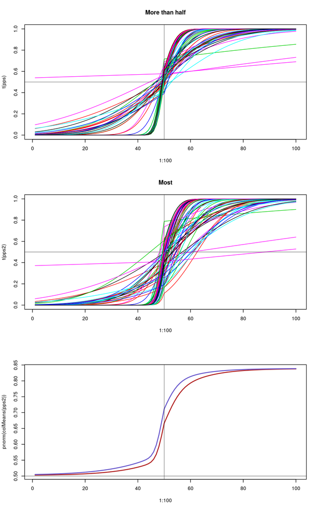

```r
pMeans <- colMeans(pEst)

I <- predat$I
pBeta0 <- pMeans[1:I]
pBeta1 <- pMeans[(I + 1):(2 * I)]
pBeta2 <- pMeans[(2*I + 1):(3 * I)]
pBeta3 <- pMeans[(3*I + 1):(4 * I)]

below <- c((1:50 - 50)/100, rep(0, 50))
mbelow <- matrix(rep(below, I), nrow = I, byrow = T)
above <- c(rep(0, 50), (51:100 - 50)/100)
mabove <- matrix(rep(above, I), nrow = I, byrow = T)
sided <- c(rep(0, 50), rep(1, 50))
msided <- matrix(rep(sided, I), nrow = I, byrow = T)

layout(matrix(1:3, ncol = 1))

pMu <- matrix(rep(pBeta0, 100), ncol = 100) + mbelow * pBeta1 + mabove * pBeta2
pps <- pnorm(pMu)

matplot(1:100, t(pps), type = "l", lty = 1, main = "More than half")
abline(h = .5, col = adjustcolor(1, .5))
abline(v = 50, col = adjustcolor(1, .5))

pMu2 <- matrix(rep(pBeta0, 100), ncol = 100) + mbelow * pBeta1 + mabove * pBeta2 + matrix(rep(pBeta3, 100), ncol = 100)
pps2 <- pnorm(pMu2)

matplot(1:100, t(pps2), type = "l", lty = 1, main = "Most")
abline(h = .5, col = adjustcolor(1, .5))
abline(v = 50, col = adjustcolor(1, .5))

plot(1:100, pnorm(colMeans(pps2)), type = "l", lwd = 2, col = "firebrick")
lines(1:100, pnorm(colMeans(pps)), lwd = 2, col = "slateblue")
abline(h = .5, col = adjustcolor(1, .5))
abline(v = 50, col = adjustcolor(1, .5))
```

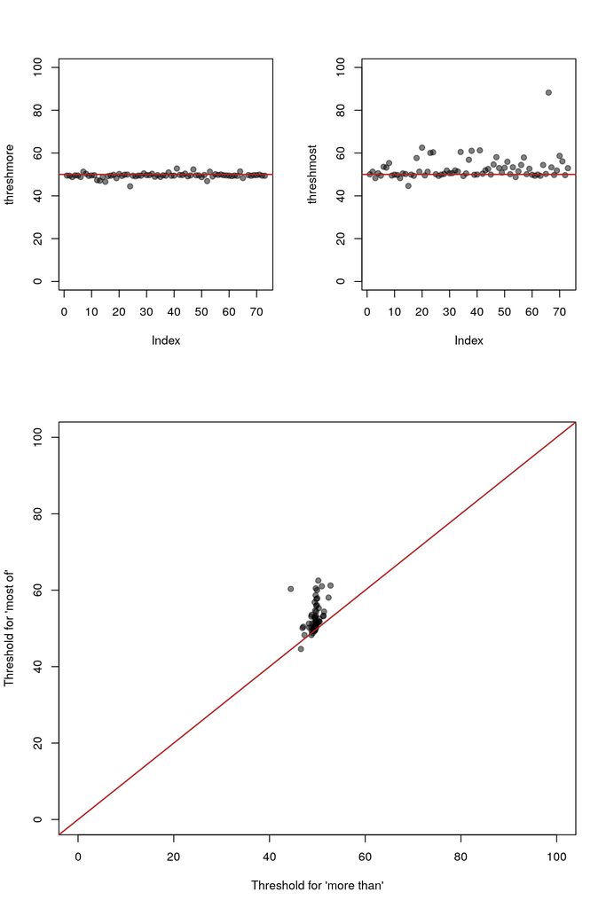

```r
threshmore <- ifelse((-pBeta0/pBeta2 * 100 + 50) > 50
                     , -pBeta0/pBeta2 * 100 + 50
                     , -pBeta0/pBeta1 * 100 + 50)
threshmost <- ifelse(((-pBeta0 - pBeta3)/pBeta2 * 100 + 50) > 50
                     , (-pBeta0 - pBeta3)/pBeta2 * 100 + 50
                     , (-pBeta0 - pBeta3)/pBeta1 * 100 + 50)


layout(matrix(c(1,2,3,3), ncol = 2, byrow = T), heights = c(.4, .6))

plot(threshmore, pch = 19, col = adjustcolor(1, .5), ylim = c(0, 100))
abline(h = 50, lwd = 1.5, col = "firebrick")
plot(threshmost, pch = 19, col = adjustcolor(1, .5), ylim = c(0, 100))
abline(h = 50, lwd = 1.5, col = "firebrick")

plot(threshmore, threshmost
     , pch = 19, col = adjustcolor(1, .5)
     , ylab = "Threshold for 'most of'"
     , xlab = "Threshold for 'more than'"
     , xlim = c(0, 100)
     , ylim = c(0, 100))
abline(0, 1, lwd = 1.5, col = "firebrick")
```

```r
pCIs <- apply(pEst, 2, quantile, probs = c(.025, .975))

ciBeta3 <- pCIs[, (3*I + 1):(4 * I)]
```

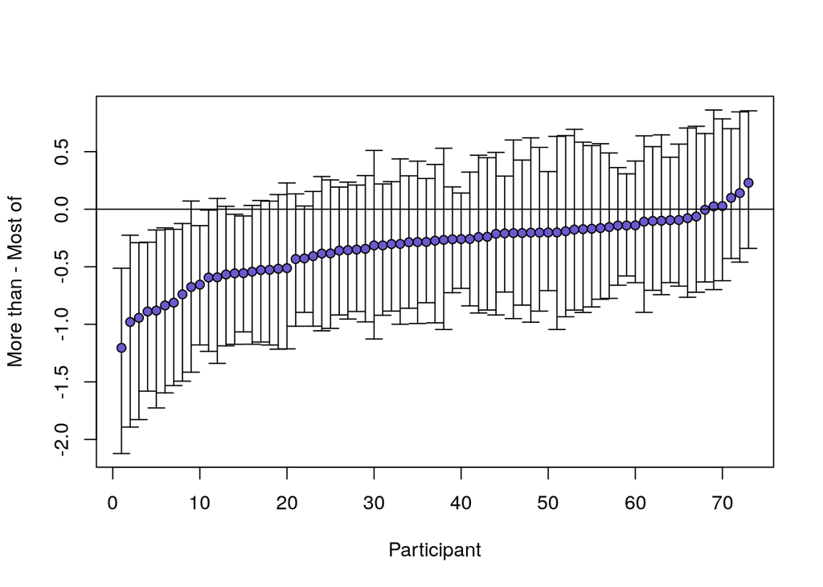

```r
indord <- order(pBeta3)
plotCI(1:I, pBeta3[indord]
       , ui = ciBeta3[2, indord], li = ciBeta3[1, indord]
       , pch = 21, pt.bg = "slateblue"
       , ylab = "More than - Most of"
       , xlab = "Participant")
abline(h = 0)
```

```r
## Prior probability
M <- 100000
s2 <- rinvgamma(M, 2, .1)
beta3 <- rnorm(M, 0, .1)

prioreff <- exp(pnorm(0, beta3, sqrt(s2), lower.tail = T, log.p = T) * I)
priorneg <- mean(prioreff)

## Posterior Probability
targ <- pEst[, (3*I + 1):(4 * I)]
good <- targ < 0 #evaluate their sign
all.good <- apply(good, 1, mean) #evaluate how often all theta estimates are postitive
postneg <- mean(all.good == 1) #Posterior probability of all theta_i being positive

priorneg
```

```
## [1] 0.0002307503
```

```r
postneg
```

```
## [1] 0.00125
```

```r
postneg/priorneg
```

```
## [1] 5.417112
```